# Phytoplankton in Northern Michigan Lakes

Ellie Frank

22 May, 2020

# Packages and Data

```r
library(tidyverse)
```

```r
df <- read.csv("phytoplankton.csv")%>%
  filter(division=="Chlorophyta" | division == "Bacillariophyta" |
           division == "Chrysophyta" | division == "Cyanophyta")%>%
  filter(year4 %in% (1984:1995))
str(df)
head(df)
```

[output not shown]

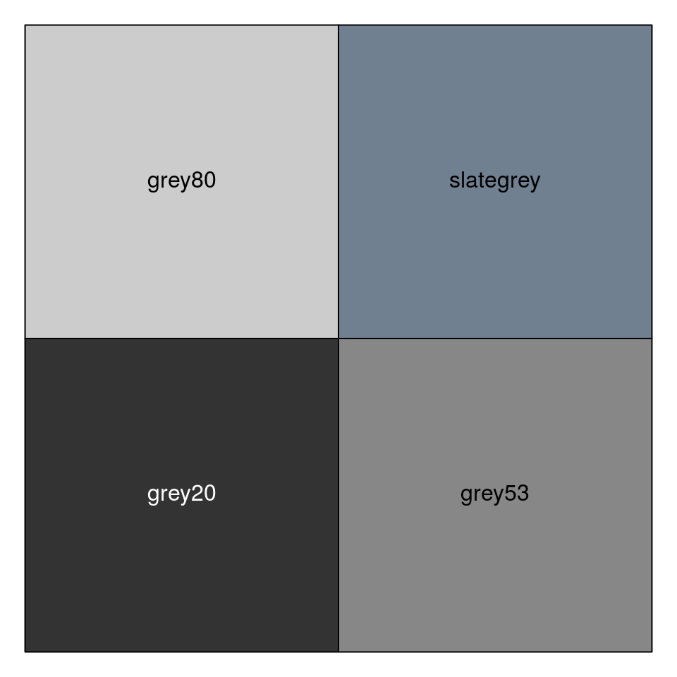

```r
clrs <- c("grey80","slategrey","grey20","grey53")
scales::show_col(clrs)
```

These are the colors I will be using in my plots. I chose them because they are neutral and simple, and different enough that the viewer can easily tell them apart.

# Introduction

Phytoplankton are an important part of ecosystems. They are the base of many aquatic food chains, and their presence can tell us a lot about nutrient levels in both fresh and salt water systems. Because of this, scientists S. Carpenter, J. Kitchell, J. Cole, and M. Pace collected data on phytoplankton in a group of freshwater lakes in Northern Michigan, near the Wisconsin border from 1984 through 1995. They found over 36 different phylums of phytoplanktons between all five lakes, and thousands of different genuses. Years later, their research was picked back up by Phycotech Inc., from 2013 to 2015. For the purposes of this assignment, we will only be using the data from the former time frame.

No phylums that include phytoplankton are exclusively freshwater or exclusively salt water, but some show greater abundance in one category than the other. The most common phylums people see in freshwater are Chlorophyta (green algae), Cyanophyta (cyanobacteria, or blue-green algae), Chrysophyta (brown algae), Rhodophyta (red algae), and Bacillariophyta (diatoms). The following plots will be about these phylums, except for Rhodophyta, as there were no samples found during the 1984-1995 time period.

After looking at the initial data table, I decided that the two questions I wanted to answer were as follows: Whhat types of phytoplankton were most common in each lake, and how did the amounts of each type change over time?

# Plotting the Data

```r
df_sum2 <- df %>%
  group_by(lakename,division) %>%
  summarize(freq=n()) %>%
  mutate(perc=freq/sum(freq)*100) %>%
  ungroup()
df_sum2
```

```
#R> # A tibble: 20 x 4
#R>    lakename       division         freq  perc
#R>    <fct>          <fct>           <int> <dbl>
#R>  1 East Long Lake Bacillariophyta    52  4.95
#R>  2 East Long Lake Chlorophyta       473 45.0
#R>  3 East Long Lake Chrysophyta       452 43.0
#R>  4 East Long Lake Cyanophyta         73  6.95
#R>  5 Paul Lake      Bacillariophyta    99  2.48
#R>  6 Paul Lake      Chlorophyta      1721 43.1
#R>  7 Paul Lake      Chrysophyta      1438 36.0
#R>  8 Paul Lake      Cyanophyta        731 18.3
#R>  9 Peter Lake     Bacillariophyta   116  3.29
#R> 10 Peter Lake     Chlorophyta      1663 47.2
#R> 11 Peter Lake     Chrysophyta      1156 32.8
#R> 12 Peter Lake     Cyanophyta        592 16.8
#R> 13 Tuesday Lake   Bacillariophyta   107  6.64
#R> 14 Tuesday Lake   Chlorophyta       665 41.3
#R> 15 Tuesday Lake   Chrysophyta       717 44.5
#R> 16 Tuesday Lake   Cyanophyta        123  7.63
#R> 17 West Long Lake Bacillariophyta    16  1.35
#R> 18 West Long Lake Chlorophyta       546 46.0
#R> 19 West Long Lake Chrysophyta       432 36.4
#R> 20 West Long Lake Cyanophyta        192 16.2
```

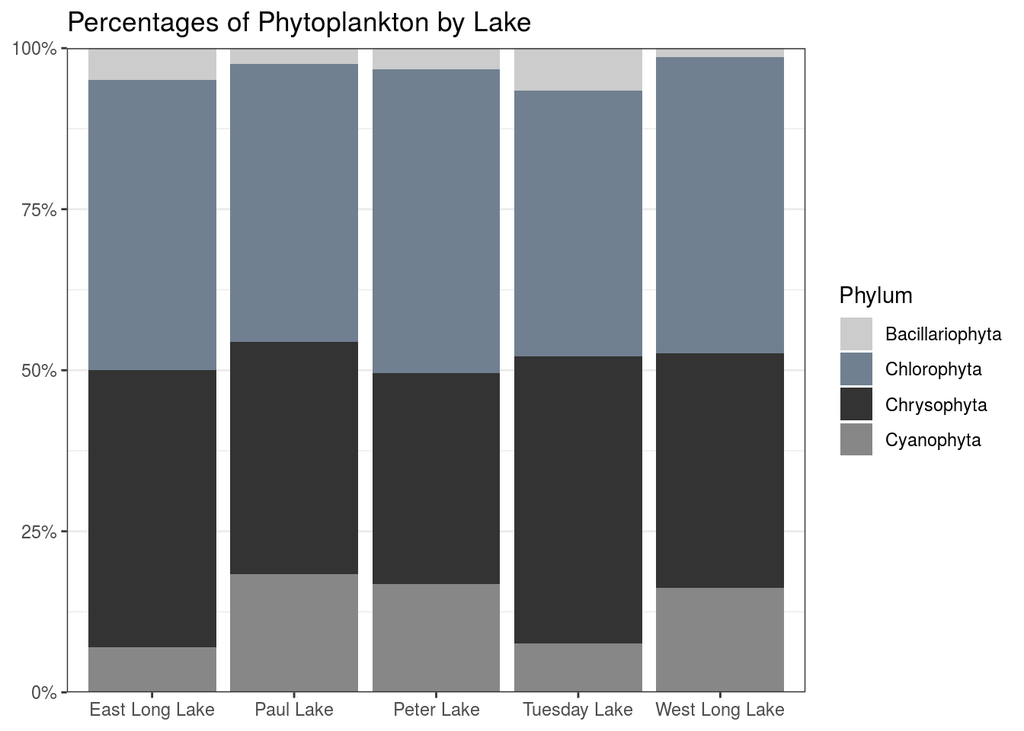

```r
ggplot(data=df_sum2,
       mapping=aes(x=lakename, y=perc, fill=division)) +
  geom_bar(stat="identity") +
  scale_y_continuous(name=NULL,
                     expand=expansion(mult=0),
                     labels=scales::label_percent(scale=1,accuracy=1)) +
  scale_x_discrete(name=NULL) +
  theme_bw() +
    theme(panel.grid.major.x=element_blank(),
        panel.grid.minor.x=element_blank()) +
  scale_fill_manual(name="Phylum",
                    values=c(clrs)) +
      labs(title="Percentages of Phytoplankton by Lake")
```

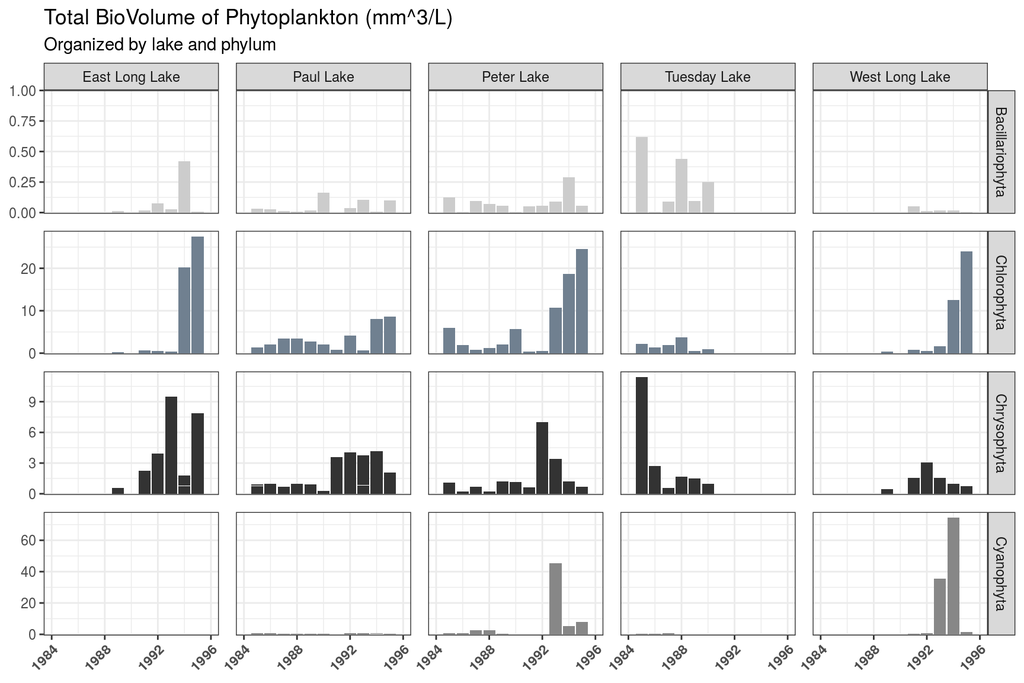

```r
ggplot(data=df,
       mapping=aes(x=year4, y=total_biovol,
                   fill=division)) +
  geom_histogram(stat="identity") +
  scale_x_continuous(name=NULL,
                     breaks=seq(0,1996,4),
                     limits = c(1984,1996)) +
  scale_y_continuous(name=NULL,
                     expand=expansion(mult=c(0.01,0.05))) +
  facet_grid(rows=vars(division),
             cols=vars(lakename),
             scales="free_y") +
  theme_bw() +
  scale_fill_manual(values=c(clrs)) +
  theme(legend.position="none",
        axis.text.x = element_text(face="bold",
                                   angle = 45,
                                   hjust = 1),
        panel.spacing = unit(0.75, "lines")) +
    labs(title="Total BioVolume of Phytoplankton (mm^3/L)",
         subtitle="Organized by lake and phylum")
```

I chose to facet these plots because when combined into one plot, or even when only seperated out by one variable, they read as very messy. By Seperating them by both lake and phylum, the reader is able to easily see the trend in biovolume for each group of phytoplankton within each lake over a period of time. I used a free y-scale so that each phylum’s row of plots could be easily visible to the reader, because as you can see, there is a huge difference between the biovolumes of each phylum.

Chrysophyta and Basillariophyta had mixed trends within each lake. While in East Long Lake and Peter Lake there was a spike in Chrysophyta around 1992-1993, Tuesday Lake’s biovolume decreased throughout time, and Paul Lake remained steady, with the jump in 1991 mostly holding its numbers in the following years. All of the lakes generally followed the same trend for Bacillariophyta, with lower total volumes.

Data Source for both plots: Carpenter, S., J. Kitchell, J. Cole, and M. Pace. 2017. Cascade Project at North Temperate Lakes LTER Core Data Phytoplankton 1984 - 2015 ver 4. Environmental Data Initiative. https://doi.org/10.6073/pasta/364622a6632f857289f9abc6a99d3ae7. Accessed 2020-05-16.

Sources for Introduction/background: Wehr, John D., et al. Freshwater Algae of North America: Ecology and Classification. Chapter 2. Academic Press, 2003, https://www.sciencedirect.com/topics/biochemistry-genetics-and-molecular-biology/freshwater-alga. Freshwater Algae. Native Plants, Department of Conservation (NZ), www.doc.govt.nz/nature/native-plants/freshwater-algae/.